# daily wow tag quicklook update

wrc

2024-04-04

# 1 NOTES

additional diagnostics:

- detailed look at tx info
- detailed look at ba diel pattern

# 2 setup

Run this daily to get a snapshot of tag stats and health

## 2.1 PATH TO LATEST DATA

```r
# paths to update when you run
portaldir <- "../../01_data/portal_downloads_2023/"
metadatapath <- "../../01_data/quicklookmeta.csv"
datadirss <- list.files(portaldir)
datadir <- file.path(portaldir, datadirss[length(datadirss)])
```

## 2.2 basic helper function

## 2.3 load paths adjust as needed

## 2.4 Import data from wildlife portal and the goniometer. Merge the two stacks.

disabled still need goniometer from second boat

# 3 tag summary

|  | ptt | hex | serial | tag_model | deployid | catalog_ID_DUML | WOW_season | deploydate_yyyymmdd | deploytime_hhmm | species | location | tagger | permit | tagtype | longitude | latitude | tagside | taglocation | taglocationnotes | programming_basic_descriptor | notes | recorder | age | sex | agesex_conf | headshot | agesex_reason | appearance_notes |
| --- | --- | --- | --- | --- | --- | --- | --- | --- | --- | --- | --- | --- | --- | --- | --- | --- | --- | --- | --- | --- | --- | --- | --- | --- | --- | --- | --- | --- |
| 7 | 250574 | NA |  | SPLASH10-333 | BaTag01 | NA | WOW1 | 20230907 | 0 | Bac | NYB | DLW | NA | NA | NA | NA | NA | NA | NA | NA | NA | NA | NA | NA | NA | NA | NA | NA |
| 5 | 250569 | NA |  | SPLASH10-333 | BaTag02 | NA | WOW1 | 20230907 | 0 | Bac | NYB | DLW | NA | NA | NA | NA | NA | NA | NA | NA | NA | NA | NA | NA | NA | NA | NA | NA |
| 1 | 250571 | NA |  | SPLASH10-333 | BpTag01 | NA | WOW1 | 20230905 | 0 | Bph | NYB | DLW | NA | NA | NA | NA | NA | NA | NA | NA | NA | NA | NA | NA | NA | NA | NA | NA |
| 2 | 250576 | NA | 23U1994 | SPOT6-365 | BpTag02 | NA | WOW1 | 20230906 | 0 | Bph | NYB | DLW | NA | NA | NA | NA | NA | NA | NA | NA | NA | NA | NA | NA | NA | NA | NA | NA |
| 9 | 250573 | NA |  | SPLASH10-333 | BpTag03 | NA | WOW1 | 20230911 | 0 | Bph | NYB | DLW | NA | NA | NA | NA | NA | NA | NA | NA | NA | NA | NA | NA | NA | NA | NA | NA |
| 3 | 250575 | NA | 23U1992 | SPOT6-365 | MnTag01 | NA | WOW1 | 20230902 | 0 | Mno | NYB | DLW | NA | NA | NA | NA | NA | NA | NA | NA | NA | NA | NA | NA | NA | NA | NA | NA |
| 4 | 250572 | NA |  | SPLASH10-333 | MnTag02 | NA | WOW1 | 20230902 | 0 | Mno | NYB | DLW | NA | NA | NA | NA | NA | NA | NA | NA | NA | NA | NA | NA | NA | NA | NA | NA |
| 6 | 250570 | NA |  | SPLASH10-333 | MnTag03 | NA | WOW1 | 20230907 | 0 | Mno | NYB | DLW | NA | NA | NA | NA | NA | NA | NA | NA | NA | NA | NA | NA | NA | NA | NA | NA |
| 8 | 250579 | NA | 23U1997 | SPOT6-365 | MnTag04 | NA | WOW1 | 20230910 | 0 | Mno | NYB | DLW | NA | NA | NA | NA | NA | NA | NA | NA | NA | NA | NA | NA | NA | NA | NA | NA |

# 4 calculate stats

# 5 summaries

## 5.1 status and corrupt

|  | deployid | ptt | nmsg | ncrc | transmits | battvoltrange | zerodepthrange | last_sta_recieved | ncorrupt |
| --- | --- | --- | --- | --- | --- | --- | --- | --- | --- |
| 6 | BaTag01 | 250574 | 59 | 56 | 22215 | 3.376 to 3.568 | 0 to 2 | 2023-10-26 15:56:03 | 997 |
| 1 | BaTag02 | 250569 | 33 | 32 | 5609 | 3.376 to 3.504 | 1 to 3 | 2023-09-22 02:03:40 | 275 |
| 3 | BpTag01 | 250571 | 3 | 2 | 1410 | 3.504 to 3.504 | 1 to 1 | 2023-09-15 14:21:10 | 55 |
| 8 | BpTag02 | 250576 | 3615 | 90 | 48829 | 3.4 to 3.525 | Inf to -Inf | 2023-11-22 03:56:52 | 452 |
| 5 | BpTag03 | 250573 | 2 | 2 | 1862 | 3.376 to 3.376 | 2 to 2 | 2023-09-16 14:45:28 | 112 |
| 7 | MnTag01 | 250575 | 550 | 18 | 4132 | 3.55 to 3.6 | Inf to -Inf | 2023-09-08 18:41:39 | 46 |
| 4 | MnTag02 | 250572 | 18 | 16 | 4036 | 3.312 to 3.568 | 0 to 1 | 2023-09-08 01:54:07 | 93 |
| 2 | MnTag03 | 250570 | 10 | 9 | 2417 | 3.184 to 3.44 | 0.5 to 1 | 2023-09-10 13:14:46 | 68 |
| 9 | MnTag04 | 250579 | 182 | 6 | 2461 | 3.425 to 3.525 | Inf to -Inf | 2023-09-14 03:42:27 | 20 |

## 5.2 locations

|  | deployid | ptt | nloc | nz | na | nb | n0 | n1 | n2 | n3 | last_loc_recieved |
| --- | --- | --- | --- | --- | --- | --- | --- | --- | --- | --- | --- |
| 6 | BaTag01 | 250574 | 1152 | 4 | 224 | 636 | 181 | 65 | 24 | 18 | 2023-10-27 13:14:25 |
| 1 | BaTag02 | 250569 | 406 | 0 | 93 | 190 | 65 | 40 | 12 | 6 | 2023-09-22 12:22:56 |
| 3 | BpTag01 | 250571 | 55 | 0 | 3 | 52 | 0 | 0 | 0 | 0 | 2023-09-22 16:13:19 |
| 8 | BpTag02 | 250576 | 1471 | 1 | 242 | 714 | 199 | 174 | 83 | 58 | 2023-11-22 03:56:52 |
| 5 | BpTag03 | 250573 | 122 | 0 | 10 | 106 | 4 | 2 | 0 | 0 | 2023-09-22 03:41:15 |
| 7 | MnTag01 | 250575 | 163 | 1 | 20 | 37 | 30 | 36 | 26 | 13 | 2023-09-08 18:37:48 |
| 4 | MnTag02 | 250572 | 105 | 0 | 11 | 19 | 27 | 26 | 12 | 10 | 2023-09-08 01:53:46 |
| 2 | MnTag03 | 250570 | 107 | 1 | 18 | 37 | 40 | 8 | 1 | 2 | 2023-09-11 12:13:35 |
| 9 | MnTag04 | 250579 | 82 | 0 | 12 | 47 | 3 | 8 | 6 | 6 | 2023-09-14 03:42:26 |

## 5.3 behavior

n/a

## 5.4 series

disabled for now

## 5.5 fastloc

n/a

# 6 position snapshot

Plot of the last four positions for all the tags which have generated an argos position within the last 3 days

[interactive chart not shown]

# 7 plot pressure sensors

**PROVISIONAL** plot status cutoffs and bat voltage. Cutoffs are in dotted red lines. These are either:

1. healthy tags: the last status messages as a conservative cutoff and on tags that are still actively transmitting this is likely to increase
2. unhealthy pressure transducer tags: if there are 2 status messages (crc’d) where the | zerodepth | > 10 then this is the last good status message before the 1st of those two bad messages.

We have settled on a more complicated cutoff system to capture a little more very likely good data for BRS (ask wrc for details). But this gives you a general idea of approx. cutoffs and pressure transducer health.

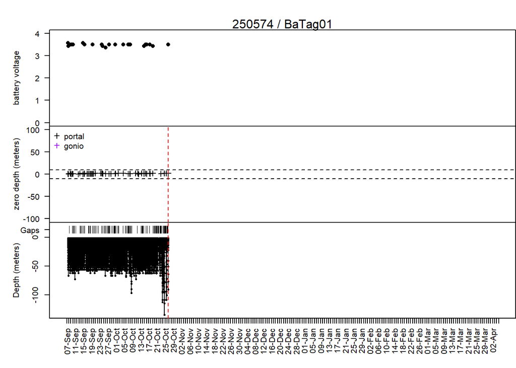

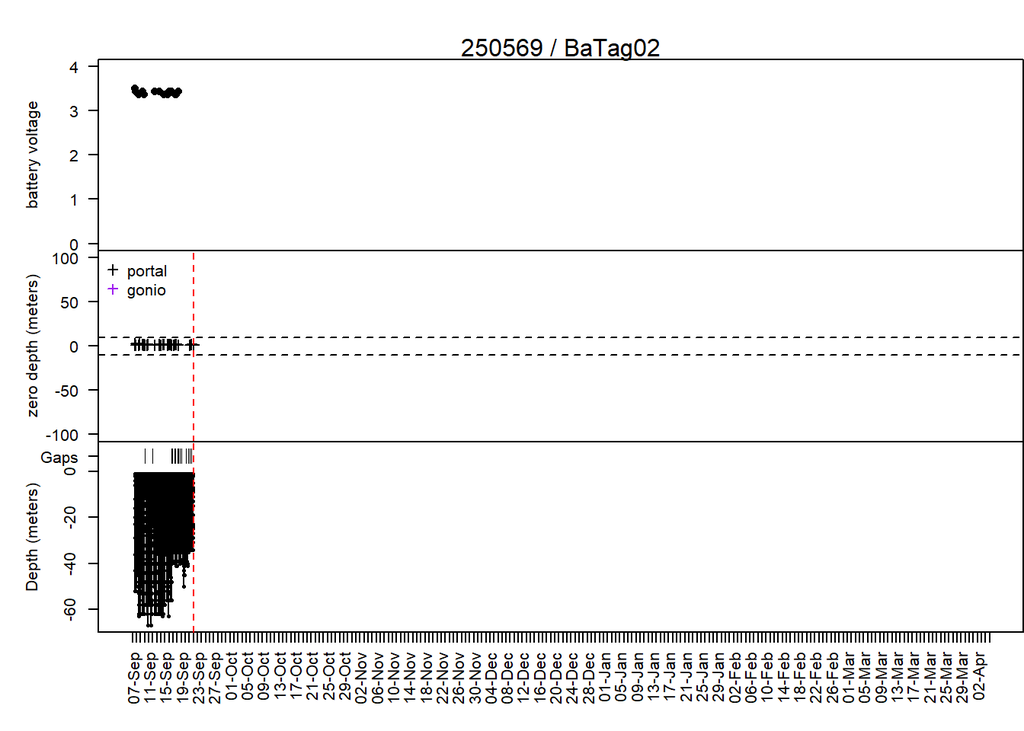

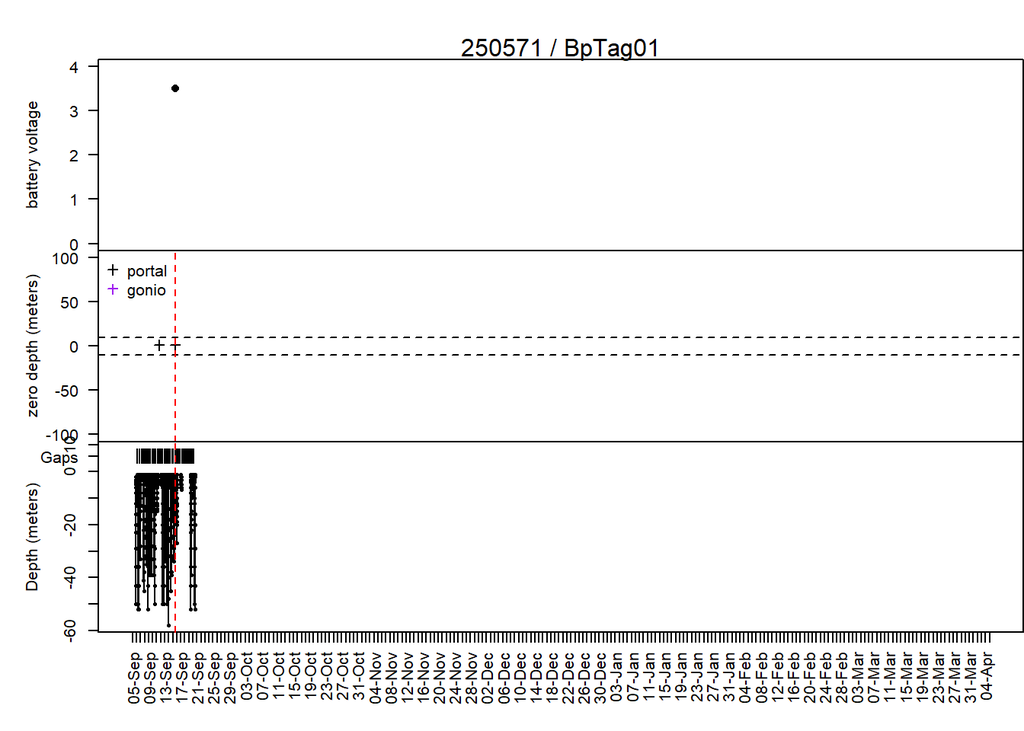

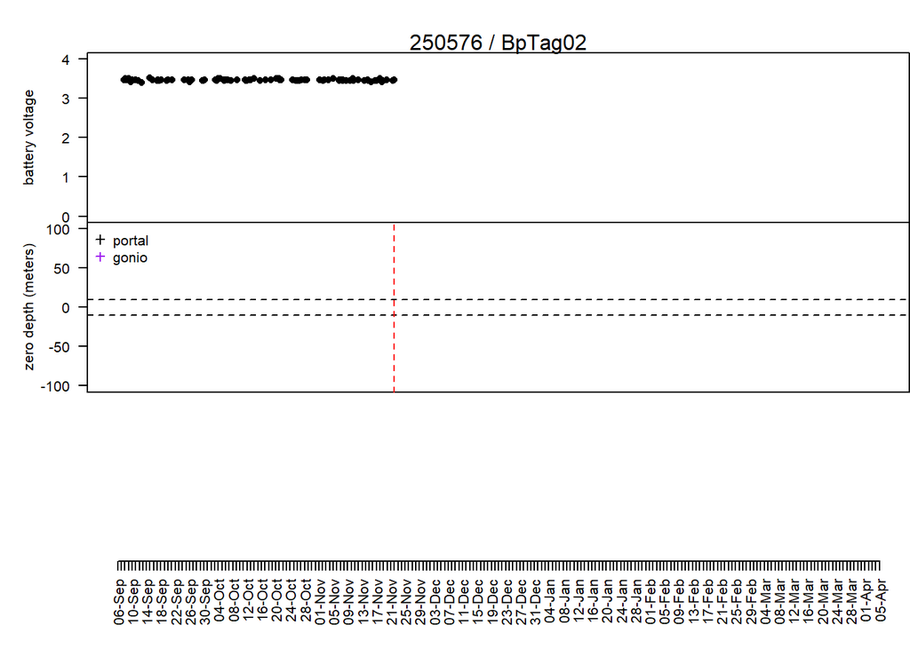

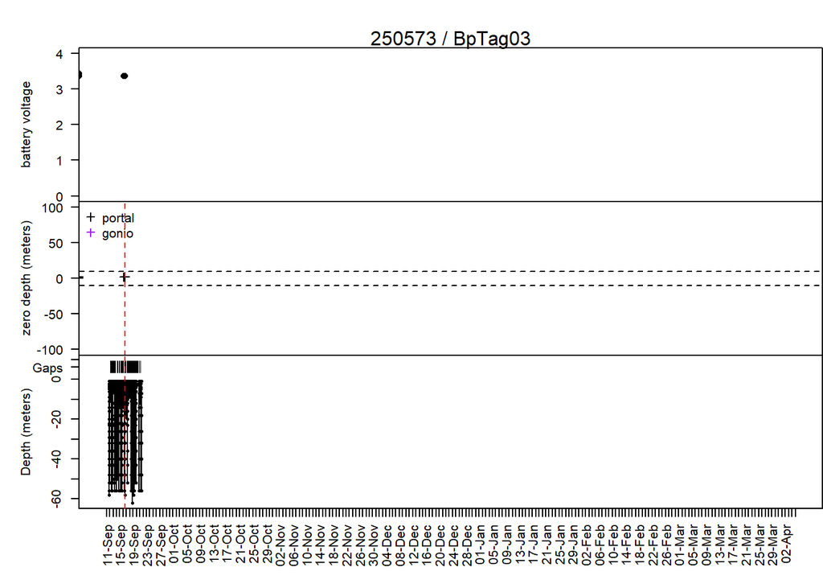

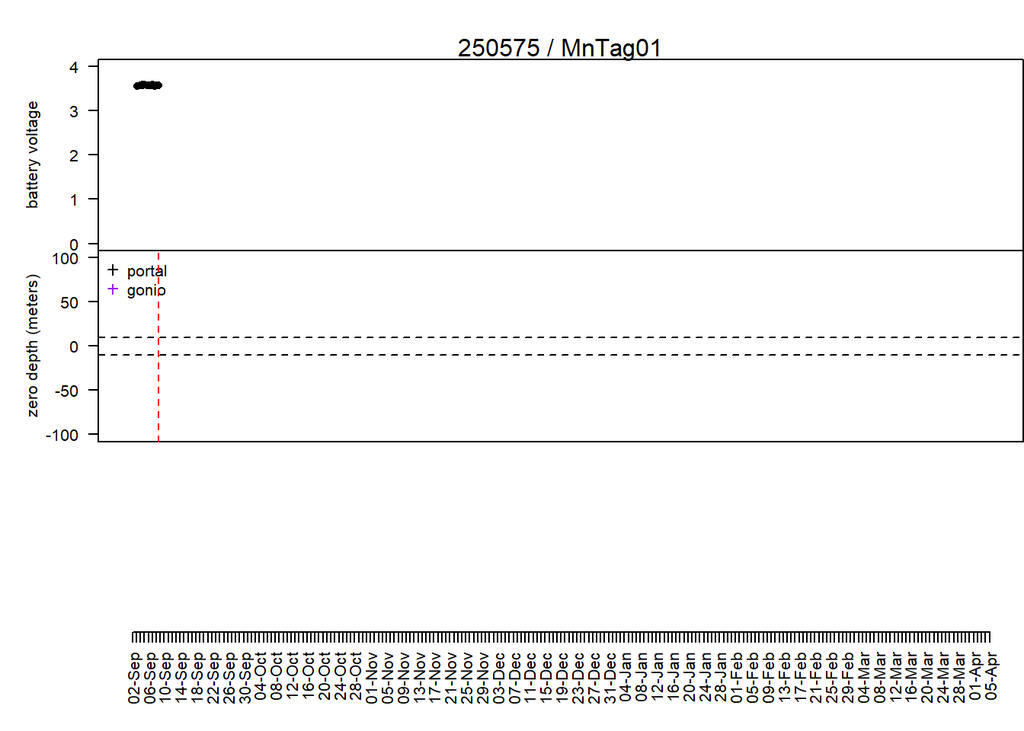

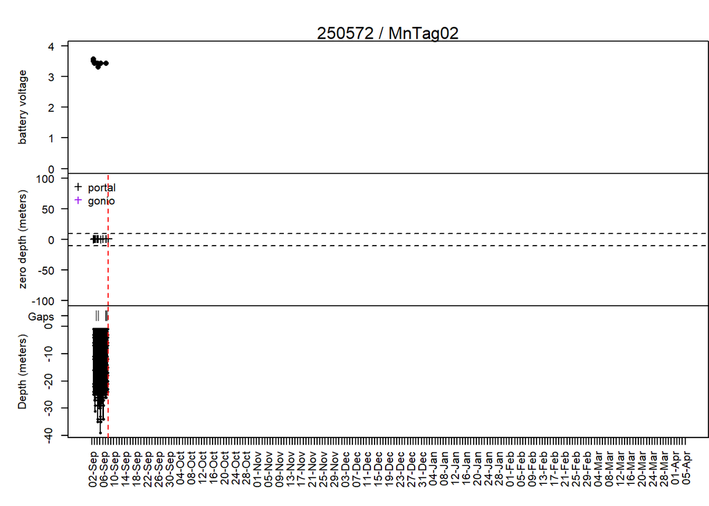

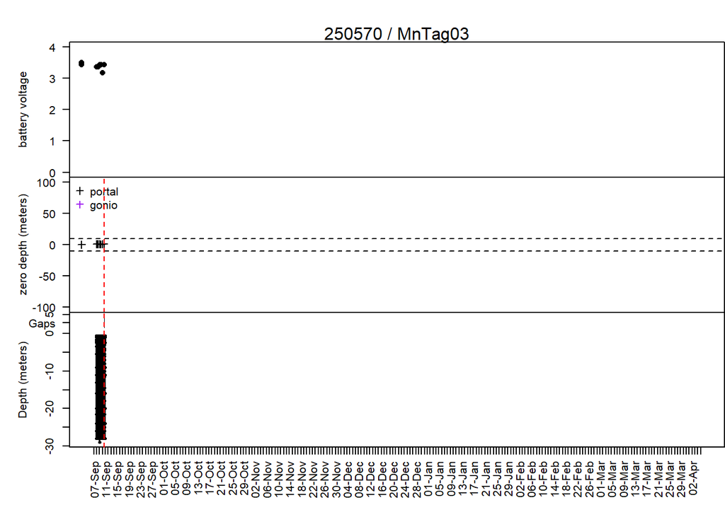

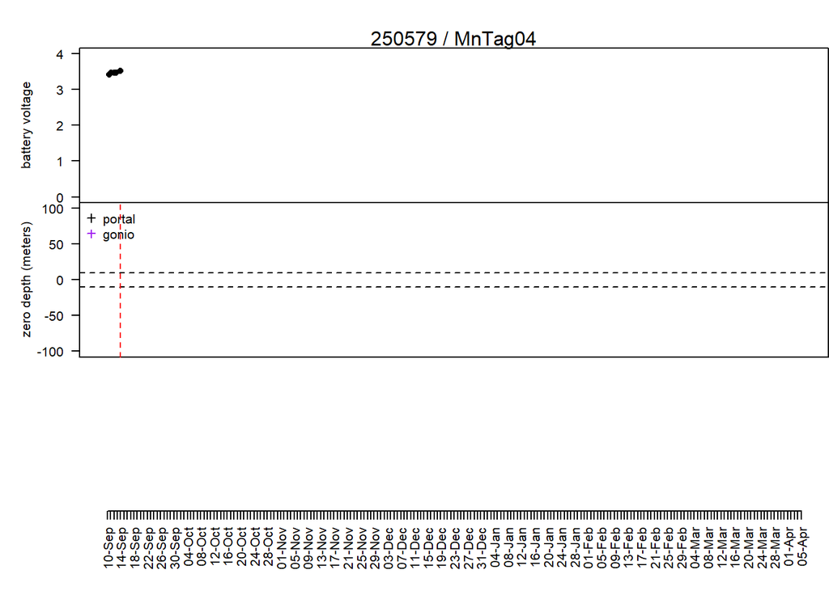

# 8 all positions

‘all’ = just qual = {0, 1, 2, 3} except for bp01 because it only hit As and Bs.

[interactive chart not shown]